# MATH 214: Homework 03

Dean Young

Due Friday 2015/3/20 5:00pm on Moodle

Note to Albert: Install the “sandwich” package.

## Question 1:

For each academic year between 2003-2004 thru 2008-2009, who were the top 10 artists played? Define

- the start of academic year as the first Tuesday in September
- the end of the academic year as the last Monday in January plus 15 weeks plus 4 days (i.e. the Friday of that week)

You can find these dates manually, or with the help of lubridate functions, or entirely using lubrdiate functions. Display the results in easily digestible format.

## Question 2:

Plot a time series of the number of songs played each week. What patterns do you observe?

```
## geom_smooth: method="auto" and size of largest group is <1000, so using loess. Use 'method = x' to change the smoothing method.
```

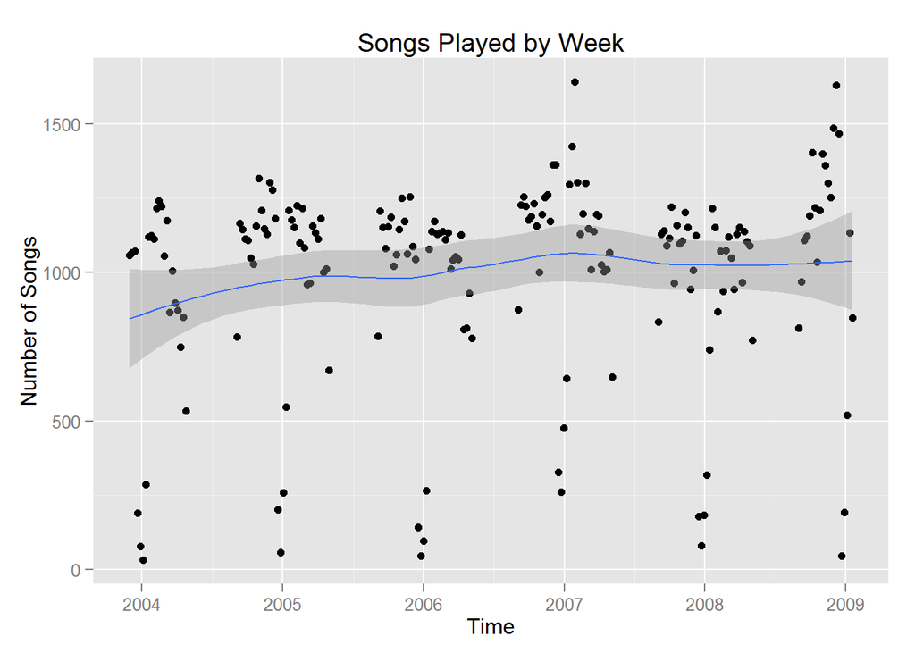

The trend of number of songs played by week seems pretty stable over the school year. The low points are around winter break which is expected. The jukebox usage seems to be on the rise at the beginning of 2009.

## Question 3:

Compare Eminem, Talking Heads, and Girl Talk’s month by month popularity over this time period.

```
## geom_smooth: method="auto" and size of largest group is <1000, so using loess. Use 'method = x' to change the smoothing method.
```

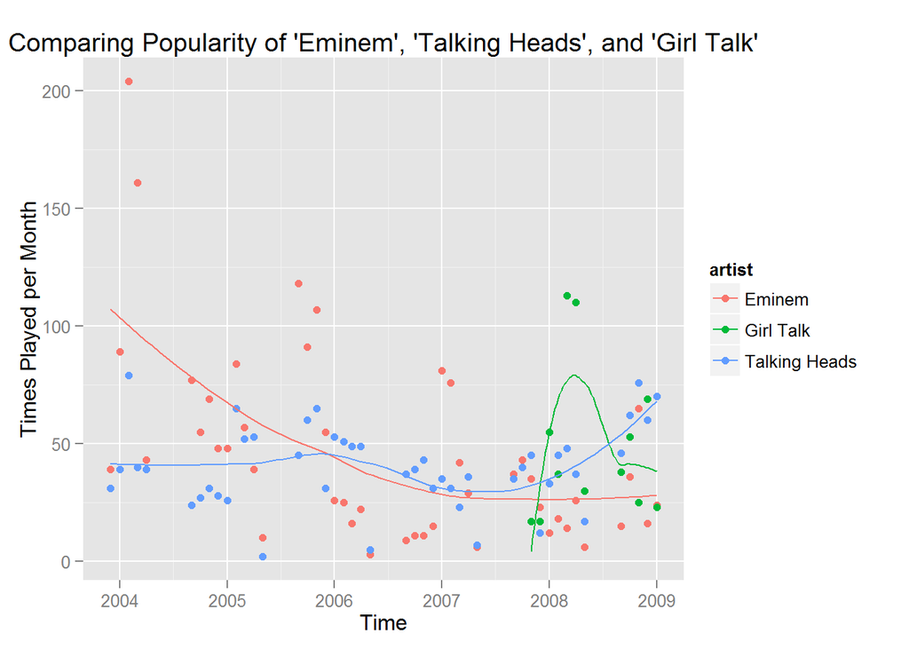

Eminem was popular around 2004 but gradually fell and eventually ended up below Talking Heads which slowly built up popularity over the years. Girl Talk had a large spike when it was first listened to but then faded away.

## Question 4:

Did jukebox using Reedies’ taste in songs change much during the period of the Sunday night blues? Define this period to be between 4pm and 11pm on Sundays.

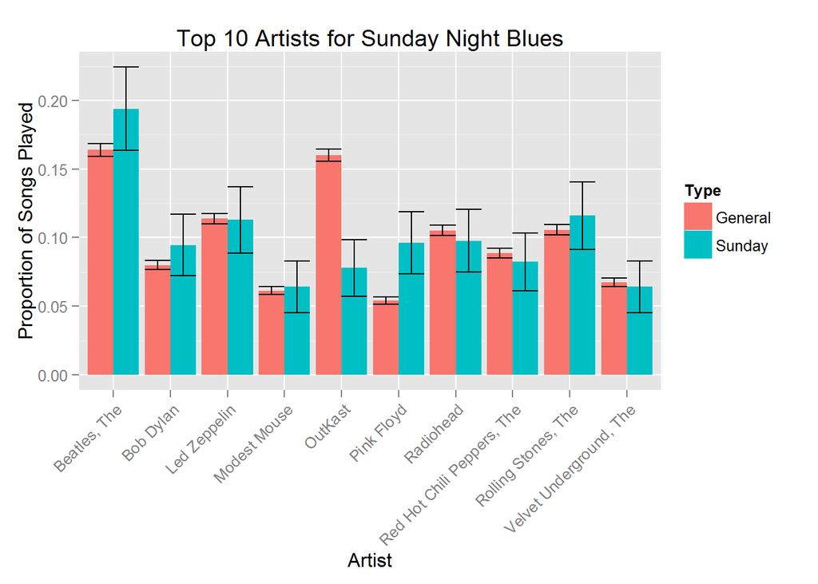

## Question 5:

We want to study the volatility of bitcoin prices. Let our measure of volatility be the relative change from day-to-day in price. For which periods since 2013/01/01 did we see the most volatility?

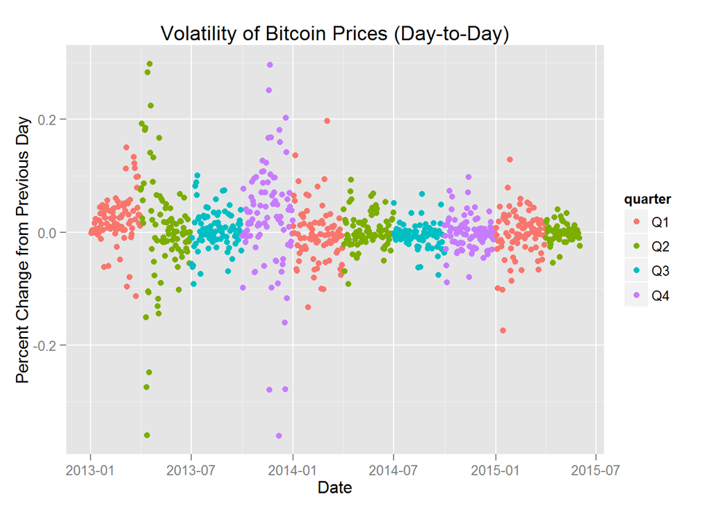

It appears that 2nd and 4th quarter of 2013 had the most price volatility. The price of bitcoins was the most stable in the 2nd and 3rd quarter of 2014.

## Question 6:

Compare the volatility of bitcoin prices with the volatility of the price of gold for the same time period. What do you observe?

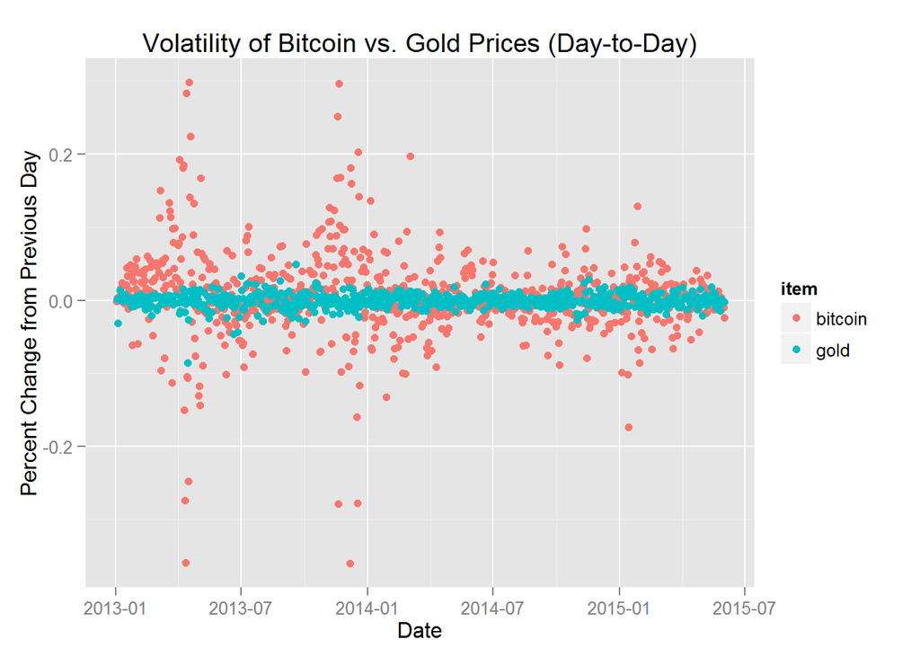

Unsurprisingly, the price of gold is much much less volatile than the price of bitcoins.

## Question 7:

Answer another question of interest to you about the jukebox data.

Which day of the week has the most songs played? (Probably Friday)

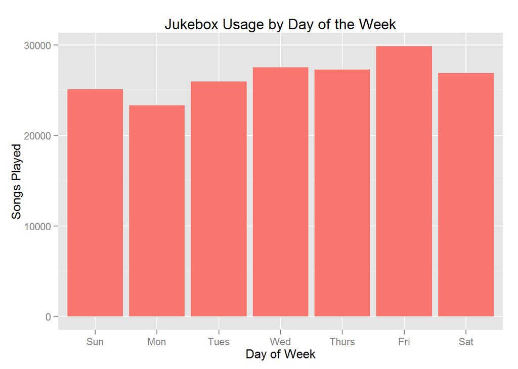

My guess was correct.

## Question 8:

Answer another question of interest to you using the data on Quandl. Preferably on a topic you are interested in.

Is the Apple stock (aapl) a stationary time series?

```
##
## Call:
## lm(formula = Close ~ lag(Close), data = aapl)
##
## Residuals:
##     Min      1Q  Median      3Q     Max
## -9.1053 -0.0964 -0.0062  0.0843  7.0620
##
## Coefficients:
##              Estimate Std. Error  t value Pr(>|t|)
## (Intercept) 0.0050464  0.0073398    0.688    0.492
## lag(Close)  1.0004123  0.0002265 4417.703   <2e-16 ***
## ---
## Signif. codes:  0 '***' 0.001 '**' 0.01 '*' 0.05 '.' 0.1 ' ' 1
##
## Residual standard error: 0.5846 on 8775 degrees of freedom
##   (1 observation deleted due to missingness)
## Multiple R-squared:  0.9996, Adjusted R-squared:  0.9996
## F-statistic: 1.952e+07 on 1 and 8775 DF,  p-value: < 2.2e-16
```

```
##               (Intercept)    lag(Close)
## (Intercept)  2.579232e-05 -2.119153e-06
## lag(Close)  -2.119153e-06  2.762652e-07
```

```
## [1] "HAC SE Corrected Confidence Interval"
## [2] "1.00097025852019"
## [3] "1.00097134147981"
```

```
## geom_smooth: method="auto" and size of largest group is >=1000, so using gam with formula: y ~ s(x, bs = "cs"). Use 'method = x' to change the smoothing method.
```

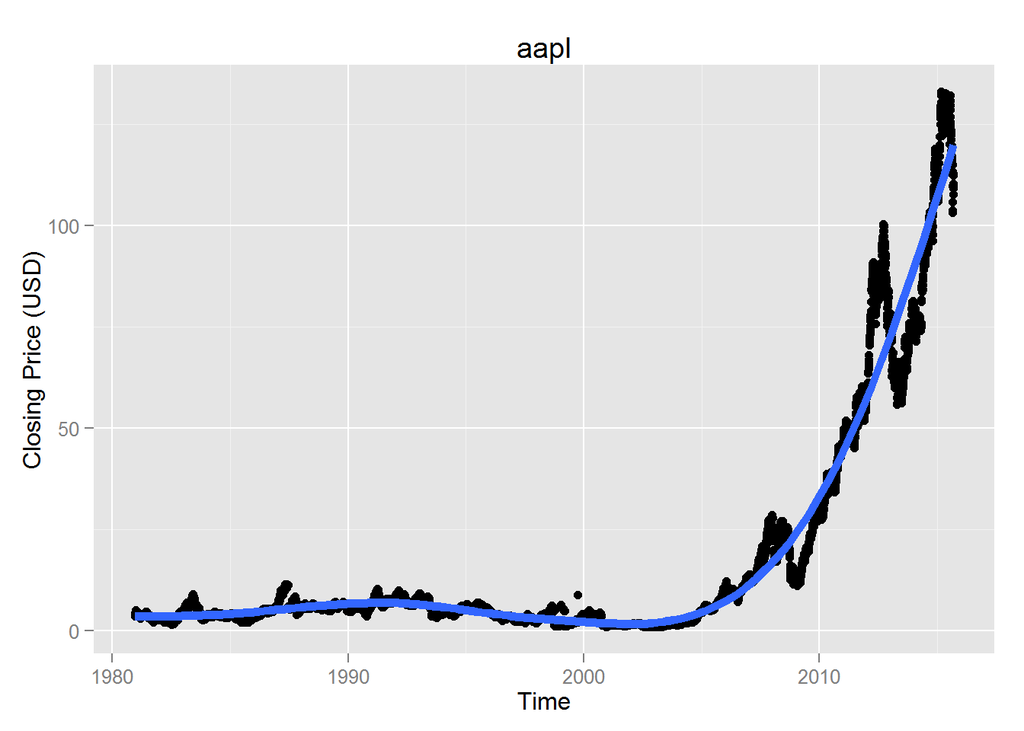